# Milestone Project

Felipe Frazatto

9/29/2020

# Introduction

Coursera’s milestone project. The main objective is to execute an exploratory data analysis of the provided data set, composed of a set of news, blogs and twitter texts.

First the data will be processed by tokenrization and stopword cleaning so that the uni, bi, tri and n-gram analysis can be efficiently done.

# Data Loading

Load all relevant libraries.

```r
library(ggplot2)
library(dplyr)
library(tm)
library(tidytext)
library(knitr)
library(kableExtra)
library(gridExtra)
library(ngram)
```

Since the data files are too large they are not present in this github project repository, but, as reproducibility is extremely important, the data can be acquired with this [link](https://d396qusza40orc.cloudfront.net/dsscapstone/dataset/Coursera-SwiftKey.zip).

Before loading the data into R, first lets explore each file sizes.

```r
# Files Paths
blogFile <- "../Data/en_US/en_US.blogs.txt"
newsFile <- "../Data/en_US/en_US.news.txt"
twitterFile <- "../Data/en_US/en_US.twitter.txt"

# Count number of lines
nLines <- c(length(readLines(blogFile, encoding = "UTF-8")),
            length(readLines(newsFile, encoding = "UTF-8")),
            length(readLines(twitterFile, encoding = "UTF-8")))

# Count number of words
nWords <- c(wordcount(readLines(blogFile, encoding = "UTF-8"), sep = " "),
            wordcount(readLines(newsFile, encoding = "UTF-8"), sep = " "),
            wordcount(readLines(twitterFile, encoding = "UTF-8"), sep = " "))

# Set file names
fName <- c("Blog",
           "News",
           "Twitter")

# Compute file sizes in megabytes
fSize <- c(round(file.size(blogFile)/2^20, 2),
           round(file.size(newsFile)/2^20, 2),
           round(file.size(twitterFile)/2^20 ,2))

# Make data frame
fileSummary <- data.frame(file = fName,
                          size = fSize,
                          nLines = nLines,
                          nWords = nWords)

# Plot table
fileSummary %>%
  kbl() %>%
  kable_paper("hover", full_width = F)
```

| file | size | nLines | nWords |
| --- | --- | --- | --- |
| Blog | 200.42 | 899288 | 37334131 |
| News | 196.28 | 1010242 | 34372530 |
| Twitter | 159.36 | 2360148 | 30373543 |

```r
# Free RAM
gc(verbose = FALSE)
```

```
##           used (Mb) gc trigger  (Mb) max used  (Mb)
## Ncells 1804776 96.4    7095576 379.0  8869470 473.7
## Vcells 5140412 39.3   49733762 379.5 51739333 394.8
```

The files are huge. Unfortunately my computer does not have the computational power to use all the data files (trust me, I tried). What I am going to do to be able to at least plot the n-grams is read 20% of each data set, sum them and use only 50% of the result.

This is a major slice in the data set which should never be done when dealing with real world problems, since it may introduce a huge bias in your model. I am only doing it because I have a decade old computer with no other alternative and this is not the final product!

```r
f1 = 0.2
f2 = 0.5

# Read the files, note the factor f1 multipling the number of lines to be read
blogData <- readLines(blogFile,
                      encoding = "UTF-8",
                      n = round(nLines[1]*f1))

newsData <- readLines(newsFile,
                      encoding = "UTF-8",
                      n = round(nLines[2]*f1))

twitterData <- readLines(twitterFile,
                         encoding = "UTF-8",
                         n = round(nLines[3]*f1))

# Concatenate results
totalData <- c(blogData, newsData, twitterData)

# Further slice the data
totalData <- totalData[1: round(length(totalData)*f2)]

# Make data frame
finalSummary <- data.frame(total.Size = format(object.size(totalData),
                                               units = "MB"),
                           total.Lines = length(totalData),
                           total.Words = wordcount(totalData))

# Plot table
finalSummary %>%
  kbl() %>%
  kable_paper("hover", full_width = F)
```

| total.Size | total.Lines | total.Words |
| --- | --- | --- |
| 108.6 Mb | 426968 | 14900335 |

```r
# Free RAM
rm(fName, fSize, nLines, nWords)
rm(blogData, newsData, twitterData)
gc(verbose = FALSE)
```

```
##            used  (Mb) gc trigger  (Mb) max used  (Mb)
## Ncells  2296647 122.7    7095576 379.0  8869470 473.7
## Vcells 17016669 129.9   49733762 379.5 51739333 394.8
```

# Data Processing

As noted before, my computer lacks the computational power to process the whole data set, however in a real world problem the data set would have to be eventually cleaned and divided into training and test sets. Here the cleaning and ngrams will be made.

## Cleaning

The cleaning processes will occur in the following order:

1- Convert all text to lowercase; 2- Substitute punctuation with blank spaces; 3- Substitute any number with blank spaces; 4- Reduce multiple spaces to only one;

When dealing with a unigram, stopwords will be removed. However, since the final product is a prediction app, removing stopwords would result in low accuracy. A list of stopwords can be found [here](https://www.ranks.nl/stopwords));

```r
# Declare function for cleaning
cleanText <- function(text) {

     newText <- text %>%
          tolower() %>%
          gsub(pattern = "[[:punct:]]", replacement =  " ") %>%
          gsub(pattern = "[0-9]", replacement = " ") %>%
          gsub(pattern = " +", replacement = " ")

     return(newText)

}

# Clean data
totalClear <- data.frame(text = cleanText(totalData))

# Free RAM
rm(totalData)
gc(verbose = FALSE)
```

```
##            used  (Mb) gc trigger (Mb) max used  (Mb)
## Ncells  2293494 122.5    7095576  379  8869470 473.7
## Vcells 16590273 126.6   59760514  456 51739333 394.8
```

## Tokenrization

Tokenrization separates the text word by word and counts the frequency that each one appears, like a histogram. Alternatively, instead of counting individual words, a bigram can be made, which counts the appearance of pair of words. This can be extended to trigrams (sequence of three words) or a n-gram (sequence of n words).

This approach is extremely useful when making a word prediction app, since it gives the most likely sequence of words that the user usually writes.

First, lets define some useful functions, so the code can be more concise.

```r
# Define function for ngram making
makeNgrams <- function(dataframe, n){

        # if it is a unigram, stopwords will be removed
        if(n == 1){

                dataframe$text <- removeWords(dataframe[,1],
                                              stopwords("english"))

                dataframe$text <- gsub("\\b[[:alpha:]]{1}\\b",
                                       dataframe[, 1],
                                       replacement = " ")
        }

        ng <- dataframe %>%
                unnest_tokens(word, text, token = "ngrams", n = n) %>%
                table() %>%
                data.frame()

        ng <- ng[order(ng$Freq, decreasing = TRUE), ]

        ng
}

# Define function for ploting the bar graphs
plotMost <- function(data, top = 10, title = "Ngram"){

        topWords <- data[1:top, ]
        names(topWords) <- c("x", "y")

        g <- ggplot(topWords, mapping = aes(x = reorder(x, -y), y = y, fill = y)) +
                geom_bar(stat = "identity",
                         color = "black") +
                labs(x = "Words", y = "Frequency", title = title) +
                theme(axis.text.x = element_text(angle = 90)) +
                scale_fill_distiller(palette="Set3")
        g

}
```

Now, lets make the ngrams.

```r
gc(verbose = FALSE)
```

```
##            used  (Mb) gc trigger (Mb) max used  (Mb)
## Ncells  2293900 122.6    7095576  379  8869470 473.7
## Vcells 16593603 126.6   59760514  456 51739333 394.8
```

```r
n1 <- totalClear %>%
        makeNgrams(1) %>%
        plotMost(top = 15, title = "Unigram")

gc(verbose = FALSE)
```

```
##            used  (Mb) gc trigger  (Mb)  max used   (Mb)
## Ncells  2550034 136.2   14211334 759.0  11145933  595.3
## Vcells 19538894 149.1  113213783 863.8 139826025 1066.8
```

```r
n2 <- totalClear %>%
        makeNgrams(2) %>%
        plotMost(top = 15, "Bigram")

gc(verbose = FALSE)
```

```
##            used  (Mb) gc trigger   (Mb)  max used   (Mb)
## Ncells  6105449 326.1   32136356 1716.3  21274556 1136.2
## Vcells 49267727 375.9  206072223 1572.3 255012894 1945.6
```

```r
n3 <- totalClear %>%
        makeNgrams(3) %>%
        plotMost(top = 15, "Trigram")

gc(verbose = FALSE)
```

```
##             used  (Mb) gc trigger   (Mb)  max used   (Mb)
## Ncells  15668422 836.8   46047348 2459.2  30759660 1642.8
## Vcells 103459995 789.4  299335188 2283.8 298445370 2277.0
```

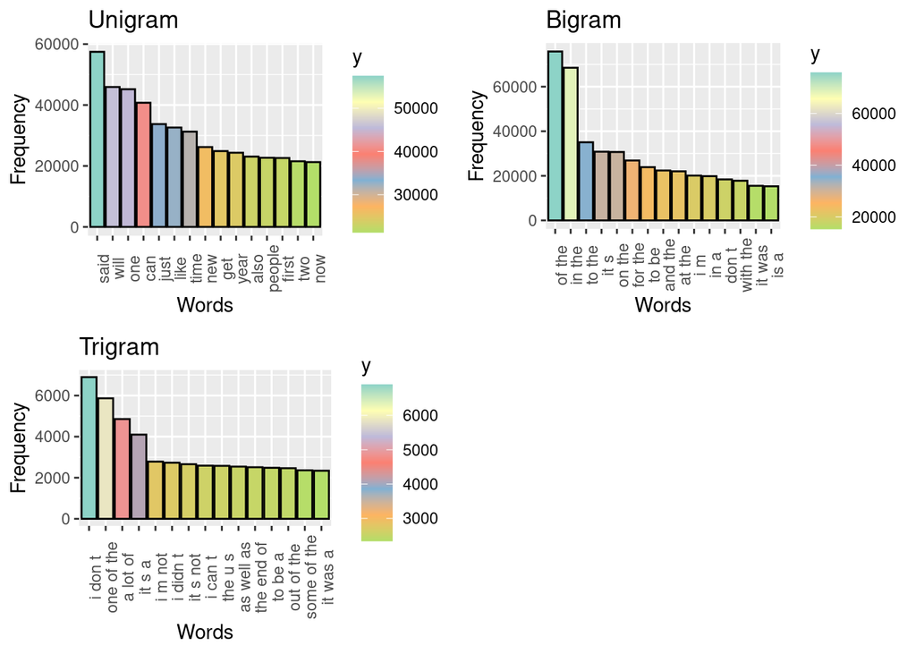

```r
grid.arrange(n1, n2, n3, nrow = 2, ncol = 2)
```

# Results

As can be seen with the ngram figures, it is possible to infer the most frequent words and suggest the next most likely word that the user could write, only based on the bi and trigrams. The model accuracy is related to the data set used, and in this particular application each user would have a particular data set, reflecting each user writing style and mannerisms. This means that the most important part of the algorithm is the constant input of data and model training.

One thing noted was that it took a lot of time and memory just to make the ngrams even with an extremely reduced data set, so for the final product it would be necessary to use a more efficient method for this step and model training.

An aspect of this kind of approach on predictive text is that the algorithm can be trained with any desired language, since it is based on probability and not grammar, rendering it very versatile.